# Practical Machine Learning - Project Write-up

Sandeep Patwardhan

Saturday, February 14, 2015

# Practical Machine Learning - Project

## Executive Summary

With technological advancement large amount of data can be collected with devices such as Jawbone Up, Fitbit etc. These type of devices are part of the quantified self movement - a group of enthusiasts who take measurements about themselves regularly to improve their health, to find patterns in their behavior, or because they are tech geeks. One thing that people regularly do is quantify how much of a particular activity they do, but they rarely quantify how well they do it. In this project, your goal will be to use data from accelerometers on the belt, forearm, arm, and dumbell of 6 participants. Using Machine learning we will predict the manner in which the exercises were done.

## Data Collection and Cleanup and necessary packages

```r
library(AppliedPredictiveModeling)
```

```r
library(caret);library(rattle);library(rpart.plot);library(randomForest)
trainUrl <- "http://d396qusza40orc.cloudfront.net/predmachlearn/pml-training.csv"
testUrl <- "http://d396qusza40orc.cloudfront.net/predmachlearn/pml-testing.csv"
trainData <- read.csv(url(trainUrl), na.strings=c("NA","#DIV/0!",""))
testData <- read.csv(url(testUrl), na.strings=c("NA","#DIV/0!",""))
colnames_train <- colnames(trainData);colnames_test <- colnames(testData)
```

- Remove any NA’s from the test data

```r
# Count the number of non-NAs in each col.
nonNAs <- function(x) {
    as.vector(apply(x, 2, function(x) length(which(!is.na(x)))))
}

# Build vector of missing data or NA columns to drop.
colcnts <- nonNAs(trainData)
drops <- c()
for (cnt in 1:length(colcnts)) {
    if (colcnts[cnt] < nrow(trainData)) {
        drops <- c(drops, colnames_train[cnt])
    }
}

trainData <- trainData[,!(names(trainData) %in% drops)]
trainData <- trainData[,8:length(colnames(trainData))]

testData <- testData[,!(names(testData) %in% drops)]
testData <- testData[,8:length(colnames(testData))]
```

- Clean up near zero var’s.

```r
nsv <- nearZeroVar(trainData, saveMetrics=TRUE)
nsv
```

```
##                      freqRatio percentUnique zeroVar   nzv
## roll_belt                1.102       6.77811   FALSE FALSE
## pitch_belt               1.036       9.37723   FALSE FALSE
## yaw_belt                 1.058       9.97350   FALSE FALSE
## total_accel_belt         1.063       0.14779   FALSE FALSE
## gyros_belt_x             1.059       0.71348   FALSE FALSE
## gyros_belt_y             1.144       0.35165   FALSE FALSE
## gyros_belt_z             1.066       0.86128   FALSE FALSE
## accel_belt_x             1.055       0.83580   FALSE FALSE
## accel_belt_y             1.114       0.72877   FALSE FALSE
## accel_belt_z             1.079       1.52380   FALSE FALSE
## magnet_belt_x            1.090       1.66650   FALSE FALSE
## magnet_belt_y            1.100       1.51870   FALSE FALSE
## magnet_belt_z            1.006       2.32902   FALSE FALSE
## roll_arm                52.338      13.52563   FALSE FALSE
## pitch_arm               87.256      15.73234   FALSE FALSE
## yaw_arm                 33.029      14.65702   FALSE FALSE
## total_accel_arm          1.025       0.33636   FALSE FALSE
## gyros_arm_x              1.016       3.27693   FALSE FALSE
## gyros_arm_y              1.454       1.91622   FALSE FALSE
## gyros_arm_z              1.111       1.26389   FALSE FALSE
## accel_arm_x              1.017       3.95984   FALSE FALSE
## accel_arm_y              1.140       2.73672   FALSE FALSE
## accel_arm_z              1.128       4.03629   FALSE FALSE
## magnet_arm_x             1.000       6.82397   FALSE FALSE
## magnet_arm_y             1.057       4.44399   FALSE FALSE
## magnet_arm_z             1.036       6.44685   FALSE FALSE
## roll_dumbbell            1.022      83.78351   FALSE FALSE
## pitch_dumbbell           2.277      81.22516   FALSE FALSE
## yaw_dumbbell             1.132      83.14137   FALSE FALSE
## total_accel_dumbbell     1.073       0.21914   FALSE FALSE
## gyros_dumbbell_x         1.003       1.22821   FALSE FALSE
## gyros_dumbbell_y         1.265       1.41678   FALSE FALSE
## gyros_dumbbell_z         1.060       1.04984   FALSE FALSE
## accel_dumbbell_x         1.018       2.16594   FALSE FALSE
## accel_dumbbell_y         1.053       2.37489   FALSE FALSE
## accel_dumbbell_z         1.133       2.08949   FALSE FALSE
## magnet_dumbbell_x        1.098       5.74865   FALSE FALSE
## magnet_dumbbell_y        1.198       4.30129   FALSE FALSE
## magnet_dumbbell_z        1.021       3.44511   FALSE FALSE
## roll_forearm            11.589      11.08959   FALSE FALSE
## pitch_forearm           65.983      14.85577   FALSE FALSE
## yaw_forearm             15.323      10.14677   FALSE FALSE
## total_accel_forearm      1.129       0.35674   FALSE FALSE
## gyros_forearm_x          1.059       1.51870   FALSE FALSE
## gyros_forearm_y          1.037       3.77637   FALSE FALSE
## gyros_forearm_z          1.123       1.56457   FALSE FALSE
## accel_forearm_x          1.126       4.04648   FALSE FALSE
## accel_forearm_y          1.059       5.11161   FALSE FALSE
## accel_forearm_z          1.006       2.95587   FALSE FALSE
## magnet_forearm_x         1.012       7.76679   FALSE FALSE
## magnet_forearm_y         1.247       9.54031   FALSE FALSE
## magnet_forearm_z         1.000       8.57711   FALSE FALSE
## classe                   1.470       0.02548   FALSE FALSE
```

## Algorithm

- I am breaking training data set (19,622 rows) into 4 different sets
- Each data set will be further split into 60% training and 40% test data sets.

```r
tr_subset <- createDataPartition(y=trainData$classe, p=0.25, list=FALSE)
tr_set1 <- trainData[tr_subset,]
tr_remain <- trainData[-tr_subset,]
set.seed(666)
tr_subset <- createDataPartition(y=tr_remain$classe, p=0.33, list=FALSE)
tr_set2 <- tr_remain[tr_subset,]
tr_remain <- tr_remain[-tr_subset,]
set.seed(666)
tr_subset <- createDataPartition(y=tr_remain$classe, p=0.5, list=FALSE)
tr_set3 <- tr_remain[tr_subset,]
tr_set4 <- tr_remain[-tr_subset,]
# Divide each of these 4 sets into training (60%) and test (40%) sets.
set.seed(666)
inTrain <- createDataPartition(y=tr_set1$classe, p=0.6, list=FALSE)
sample_training1 <- tr_set1[inTrain,]
sample_testing1 <- tr_set1[-inTrain,]
set.seed(666)
inTrain <- createDataPartition(y=tr_set2$classe, p=0.6, list=FALSE)
sample_training2 <- tr_set2[inTrain,]
sample_testing2 <- tr_set2[-inTrain,]
set.seed(666)
inTrain <- createDataPartition(y=tr_set3$classe, p=0.6, list=FALSE)
sample_training3 <- tr_set3[inTrain,]
sample_testing3 <- tr_set3[-inTrain,]
set.seed(666)
inTrain <- createDataPartition(y=tr_set4$classe, p=0.6, list=FALSE)
sample_training4 <- tr_set4[inTrain,]
sample_testing4 <- tr_set4[-inTrain,]
```

## Model Evaluation

- First I will use sample training set1 with no model features or adjustments
- This will help to determine accuracy percentage

```r
set.seed(666)
modFit <- train(sample_training1$classe ~ ., data = sample_training1, method="rpart")
print(modFit, digits=3)
```

```
## CART
##
## 2946 samples
##   52 predictor
##    5 classes: 'A', 'B', 'C', 'D', 'E'
##
## No pre-processing
## Resampling: Bootstrapped (25 reps)
##
## Summary of sample sizes: 2946, 2946, 2946, 2946, 2946, 2946, ...
##
## Resampling results across tuning parameters:
##
##   cp      Accuracy  Kappa   Accuracy SD  Kappa SD
##   0.0413  0.491     0.3375  0.0526       0.0872
##   0.0493  0.441     0.2544  0.0591       0.1029
##   0.1233  0.330     0.0695  0.0491       0.0683
##
## Accuracy was used to select the optimal model using  the largest value.
## The final value used for the model was cp = 0.0413.
```

```r
print(modFit$finalModel, digits=3)
```

```
## n= 2946
##
## node), split, n, loss, yval, (yprob)
##       * denotes terminal node
##
##  1) root 2946 2110 A (0.28 0.19 0.17 0.16 0.18)
##    2) roll_belt< 130 2666 1840 A (0.31 0.21 0.19 0.18 0.1)
##      4) pitch_forearm< -33.5 218    1 A (1 0.0046 0 0 0) *
##      5) pitch_forearm>=-33.5 2448 1840 A (0.25 0.23 0.21 0.2 0.11)
##       10) roll_forearm< 126 1599 1040 A (0.35 0.25 0.16 0.19 0.056)
##         20) magnet_dumbbell_y< 440 1331  784 A (0.41 0.19 0.18 0.16 0.054) *
##         21) magnet_dumbbell_y>=440 268  130 B (0.034 0.51 0.022 0.36 0.067) *
##       11) roll_forearm>=126 849  587 C (0.064 0.21 0.31 0.2 0.21) *
##    3) roll_belt>=130 280   10 E (0.036 0 0 0 0.96) *
```

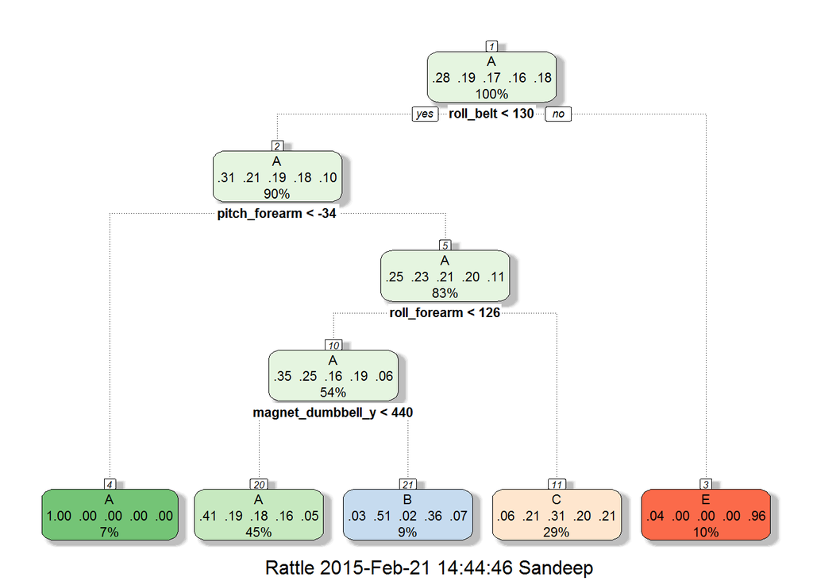

```r
fancyRpartPlot(modFit$finalModel)
```

- Running with sample test set1 as it is

```r
predictions <- predict(modFit, newdata=sample_testing1)
print(confusionMatrix(predictions, sample_testing1$classe), digits=4)
```

```
## Confusion Matrix and Statistics
##
##           Reference
## Prediction   A   B   C   D   E
##          A 501 161 153 128  47
##          B   9  99   5  55  18
##          C  45 120 184 138 114
##          D   0   0   0   0   0
##          E   3   0   0   0 181
##
## Overall Statistics
##
##                Accuracy : 0.4921
##                  95% CI : (0.4697, 0.5145)
##     No Information Rate : 0.2845
##     P-Value [Acc > NIR] : < 2.2e-16
##
##                   Kappa : 0.3381
##  Mcnemar's Test P-Value : NA
##
## Statistics by Class:
##
##                      Class: A Class: B Class: C Class: D Class: E
## Sensitivity            0.8978  0.26053  0.53801   0.0000  0.50278
## Specificity            0.6515  0.94497  0.74243   1.0000  0.99813
## Pos Pred Value         0.5061  0.53226  0.30616      NaN  0.98370
## Neg Pred Value         0.9413  0.84169  0.88382   0.8363  0.89927
## Prevalence             0.2845  0.19378  0.17440   0.1637  0.18358
## Detection Rate         0.2555  0.05048  0.09383   0.0000  0.09230
## Detection Prevalence   0.5048  0.09485  0.30648   0.0000  0.09383
## Balanced Accuracy      0.7747  0.60275  0.64022   0.5000  0.75045
```

- Results from above exercise are not impressive
- Now need to apply preprocessing cross validation technique
- This is applied on same data set used above

```r
set.seed(666)
modFit <- train(sample_training1$classe ~ .,  preProcess=c("center", "scale"), data = sample_training1, method="rpart")
print(modFit, digits=3)
```

```
## CART
##
## 2946 samples
##   52 predictor
##    5 classes: 'A', 'B', 'C', 'D', 'E'
##
## Pre-processing: centered, scaled
## Resampling: Bootstrapped (25 reps)
##
## Summary of sample sizes: 2946, 2946, 2946, 2946, 2946, 2946, ...
##
## Resampling results across tuning parameters:
##
##   cp      Accuracy  Kappa   Accuracy SD  Kappa SD
##   0.0413  0.491     0.3375  0.0526       0.0872
##   0.0493  0.441     0.2544  0.0591       0.1029
##   0.1233  0.330     0.0695  0.0491       0.0683
##
## Accuracy was used to select the optimal model using  the largest value.
## The final value used for the model was cp = 0.0413.
```

```r
set.seed(666)
modFit <- train(sample_training1$classe ~ .,  trControl=trainControl(method = "cv", number = 4), data = sample_training1, method="rpart")
print(modFit, digits=3)
```

```
## CART
##
## 2946 samples
##   52 predictor
##    5 classes: 'A', 'B', 'C', 'D', 'E'
##
## No pre-processing
## Resampling: Cross-Validated (4 fold)
##
## Summary of sample sizes: 2212, 2209, 2208, 2209
##
## Resampling results across tuning parameters:
##
##   cp      Accuracy  Kappa   Accuracy SD  Kappa SD
##   0.0413  0.510     0.3645  0.0240       0.0374
##   0.0493  0.425     0.2255  0.0606       0.1046
##   0.1233  0.325     0.0632  0.0478       0.0732
##
## Accuracy was used to select the optimal model using  the largest value.
## The final value used for the model was cp = 0.0413.
```

- Not much improvement seen
- Will apply random forest along with preprocessing and cross validation

## Random Forest

- Apply cross validation only for training set1

```r
set.seed(666)
modFit <- train(sample_training1$classe ~ ., method="rf", trControl=trainControl(method = "cv", number = 4), data=sample_training1)
print(modFit, digits=3)
```

```
## Random Forest
##
## 2946 samples
##   52 predictor
##    5 classes: 'A', 'B', 'C', 'D', 'E'
##
## No pre-processing
## Resampling: Cross-Validated (4 fold)
##
## Summary of sample sizes: 2212, 2209, 2208, 2209
##
## Resampling results across tuning parameters:
##
##   mtry  Accuracy  Kappa  Accuracy SD  Kappa SD
##    2    0.954     0.942  0.01148      0.01452
##   27    0.955     0.942  0.00774      0.00980
##   52    0.954     0.942  0.00527      0.00668
##
## Accuracy was used to select the optimal model using  the largest value.
## The final value used for the model was mtry = 27.
```

- Random forest with cross validation improved the accuracy
- Run same model with sample test set1

```r
predictions <- predict(modFit, newdata=sample_testing1)
print(confusionMatrix(predictions, sample_testing1$classe), digits=4)
```

```
## Confusion Matrix and Statistics
##
##           Reference
## Prediction   A   B   C   D   E
##          A 553  18   0   1   0
##          B   3 356  16   0   3
##          C   1   6 320  12   6
##          D   0   0   6 308   2
##          E   1   0   0   0 349
##
## Overall Statistics
##
##                Accuracy : 0.9618
##                  95% CI : (0.9523, 0.9698)
##     No Information Rate : 0.2845
##     P-Value [Acc > NIR] : < 2.2e-16
##
##                   Kappa : 0.9516
##  Mcnemar's Test P-Value : NA
##
## Statistics by Class:
##
##                      Class: A Class: B Class: C Class: D Class: E
## Sensitivity            0.9910   0.9368   0.9357   0.9595   0.9694
## Specificity            0.9865   0.9861   0.9846   0.9951   0.9994
## Pos Pred Value         0.9668   0.9418   0.9275   0.9747   0.9971
## Neg Pred Value         0.9964   0.9848   0.9864   0.9921   0.9932
## Prevalence             0.2845   0.1938   0.1744   0.1637   0.1836
## Detection Rate         0.2820   0.1815   0.1632   0.1571   0.1780
## Detection Prevalence   0.2917   0.1928   0.1759   0.1611   0.1785
## Balanced Accuracy      0.9887   0.9615   0.9601   0.9773   0.9844
```

- Run the same model with testing data downloaded (20 observations)

```r
print(predict(modFit, newdata=testData))
```

```
##  [1] B A B A A E D B A A B C B A E E A D B B
## Levels: A B C D E
```

- Running model for training set1 with preprocessing and cross validation

```r
set.seed(666)
modFit <- train(sample_training1$classe ~ ., method="rf", preProcess=c("center", "scale"), trControl=trainControl(method = "cv", number = 4), data=sample_training1)
print(modFit, digits=3)
```

```
## Random Forest
##
## 2946 samples
##   52 predictor
##    5 classes: 'A', 'B', 'C', 'D', 'E'
##
## Pre-processing: centered, scaled
## Resampling: Cross-Validated (4 fold)
##
## Summary of sample sizes: 2212, 2209, 2208, 2209
##
## Resampling results across tuning parameters:
##
##   mtry  Accuracy  Kappa  Accuracy SD  Kappa SD
##    2    0.955     0.943  0.01009      0.01277
##   27    0.956     0.944  0.00980      0.01241
##   52    0.952     0.939  0.00704      0.00893
##
## Accuracy was used to select the optimal model using  the largest value.
## The final value used for the model was mtry = 27.
```

- Apply above algorithm on testdata set1

```r
predictions <- predict(modFit, newdata=sample_testing1)
print(confusionMatrix(predictions, sample_testing1$classe), digits=4)
```

```
## Confusion Matrix and Statistics
##
##           Reference
## Prediction   A   B   C   D   E
##          A 553  19   0   1   0
##          B   3 355  14   1   2
##          C   1   6 320  11   8
##          D   0   0   8 308   2
##          E   1   0   0   0 348
##
## Overall Statistics
##
##                Accuracy : 0.9607
##                  95% CI : (0.9512, 0.9689)
##     No Information Rate : 0.2845
##     P-Value [Acc > NIR] : < 2.2e-16
##
##                   Kappa : 0.9503
##  Mcnemar's Test P-Value : 0.0005214
##
## Statistics by Class:
##
##                      Class: A Class: B Class: C Class: D Class: E
## Sensitivity            0.9910   0.9342   0.9357   0.9595   0.9667
## Specificity            0.9857   0.9873   0.9839   0.9939   0.9994
## Pos Pred Value         0.9651   0.9467   0.9249   0.9686   0.9971
## Neg Pred Value         0.9964   0.9842   0.9864   0.9921   0.9926
## Prevalence             0.2845   0.1938   0.1744   0.1637   0.1836
## Detection Rate         0.2820   0.1810   0.1632   0.1571   0.1775
## Detection Prevalence   0.2922   0.1912   0.1764   0.1622   0.1780
## Balanced Accuracy      0.9884   0.9608   0.9598   0.9767   0.9830
```

```r
print(predict(modFit, newdata=testData))
```

```
##  [1] B A B A A E D B A A B C B A E E A D B B
## Levels: A B C D E
```

- Running model for 2nd training set with preprocessing and cross validation

```r
set.seed(666)
modFit <- train(sample_training2$classe ~ ., method="rf", preProcess=c("center", "scale"), trControl=trainControl(method = "cv", number = 4), data=sample_training2)
print(modFit, digits=3)
```

```
## Random Forest
##
## 2917 samples
##   52 predictor
##    5 classes: 'A', 'B', 'C', 'D', 'E'
##
## Pre-processing: centered, scaled
## Resampling: Cross-Validated (4 fold)
##
## Summary of sample sizes: 2188, 2188, 2187, 2188
##
## Resampling results across tuning parameters:
##
##   mtry  Accuracy  Kappa  Accuracy SD  Kappa SD
##    2    0.950     0.936  0.00671      0.00843
##   27    0.947     0.932  0.01165      0.01469
##   52    0.939     0.923  0.01611      0.02036
##
## Accuracy was used to select the optimal model using  the largest value.
## The final value used for the model was mtry = 2.
```

- Apply above algorithm on testdata set2

```r
predictions <- predict(modFit, newdata=sample_testing2)
print(confusionMatrix(predictions, sample_testing2$classe), digits=4)
```

```
## Confusion Matrix and Statistics
##
##           Reference
## Prediction   A   B   C   D   E
##          A 547  14   0   1   0
##          B   3 354  12   0   0
##          C   0   8 324  19   6
##          D   1   0   2 293   5
##          E   1   0   0   5 346
##
## Overall Statistics
##
##                Accuracy : 0.9603
##                  95% CI : (0.9507, 0.9686)
##     No Information Rate : 0.2844
##     P-Value [Acc > NIR] : < 2.2e-16
##
##                   Kappa : 0.9498
##  Mcnemar's Test P-Value : NA
##
## Statistics by Class:
##
##                      Class: A Class: B Class: C Class: D Class: E
## Sensitivity            0.9909   0.9415   0.9586   0.9214   0.9692
## Specificity            0.9892   0.9904   0.9794   0.9951   0.9962
## Pos Pred Value         0.9733   0.9593   0.9076   0.9734   0.9830
## Neg Pred Value         0.9964   0.9860   0.9912   0.9848   0.9931
## Prevalence             0.2844   0.1937   0.1741   0.1638   0.1839
## Detection Rate         0.2818   0.1824   0.1669   0.1510   0.1783
## Detection Prevalence   0.2895   0.1901   0.1839   0.1551   0.1813
## Balanced Accuracy      0.9901   0.9660   0.9690   0.9582   0.9827
```

```r
print(predict(modFit, newdata=testData))
```

```
##  [1] B A B A A E D B A A B C B A E E A B B B
## Levels: A B C D E
```

- Running model for 3rd training set with preprocessing and cross validation

```r
set.seed(666)
modFit <- train(sample_training3$classe ~ ., method="rf", preProcess=c("center", "scale"), trControl=trainControl(method = "cv", number = 4), data=sample_training3)
print(modFit, digits=3)
```

```
## Random Forest
##
## 2960 samples
##   52 predictor
##    5 classes: 'A', 'B', 'C', 'D', 'E'
##
## Pre-processing: centered, scaled
## Resampling: Cross-Validated (4 fold)
##
## Summary of sample sizes: 2219, 2221, 2220, 2220
##
## Resampling results across tuning parameters:
##
##   mtry  Accuracy  Kappa  Accuracy SD  Kappa SD
##    2    0.945     0.931  0.0101       0.0127
##   27    0.951     0.938  0.0129       0.0164
##   52    0.945     0.930  0.0137       0.0174
##
## Accuracy was used to select the optimal model using  the largest value.
## The final value used for the model was mtry = 27.
```

- Apply above algorithm on testdata set3

```r
predictions <- predict(modFit, newdata=sample_testing3)
print(confusionMatrix(predictions, sample_testing3$classe), digits=4)
```

```
## Confusion Matrix and Statistics
##
##           Reference
## Prediction   A   B   C   D   E
##          A 559  20   0   0   0
##          B   1 352   7   0   4
##          C   0   5 334   6   2
##          D   0   2   3 316   7
##          E   0   2   0   1 349
##
## Overall Statistics
##
##                Accuracy : 0.9695
##                  95% CI : (0.961, 0.9767)
##     No Information Rate : 0.2843
##     P-Value [Acc > NIR] : < 2.2e-16
##
##                   Kappa : 0.9614
##  Mcnemar's Test P-Value : NA
##
## Statistics by Class:
##
##                      Class: A Class: B Class: C Class: D Class: E
## Sensitivity            0.9982   0.9239   0.9709   0.9783   0.9641
## Specificity            0.9858   0.9924   0.9920   0.9927   0.9981
## Pos Pred Value         0.9655   0.9670   0.9625   0.9634   0.9915
## Neg Pred Value         0.9993   0.9819   0.9938   0.9957   0.9920
## Prevalence             0.2843   0.1934   0.1746   0.1640   0.1838
## Detection Rate         0.2838   0.1787   0.1695   0.1604   0.1772
## Detection Prevalence   0.2939   0.1848   0.1761   0.1665   0.1787
## Balanced Accuracy      0.9920   0.9582   0.9815   0.9855   0.9811
```

```r
print(predict(modFit, newdata=testData))
```

```
##  [1] B A B A A E D D A A C C B A E E A B B B
## Levels: A B C D E
```

- Running model for 4th training set with preprocessing and cross validation

```r
set.seed(666)
modFit <- train(sample_training4$classe ~ ., method="rf", preProcess=c("center", "scale"), trControl=trainControl(method = "cv", number = 4), data=sample_training4)
print(modFit, digits=3)
```

```
## Random Forest
##
## 2958 samples
##   52 predictor
##    5 classes: 'A', 'B', 'C', 'D', 'E'
##
## Pre-processing: centered, scaled
## Resampling: Cross-Validated (4 fold)
##
## Summary of sample sizes: 2218, 2219, 2219, 2218
##
## Resampling results across tuning parameters:
##
##   mtry  Accuracy  Kappa  Accuracy SD  Kappa SD
##    2    0.947     0.932  0.0095       0.0120
##   27    0.953     0.941  0.0107       0.0136
##   52    0.943     0.928  0.0169       0.0215
##
## Accuracy was used to select the optimal model using  the largest value.
## The final value used for the model was mtry = 27.
```

- Apply above algorithm on testdata set4

```r
predictions <- predict(modFit, newdata=sample_testing4)
print(confusionMatrix(predictions, sample_testing4$classe), digits=4)
```

```
## Confusion Matrix and Statistics
##
##           Reference
## Prediction   A   B   C   D   E
##          A 552  22   0   2   0
##          B   2 342  14   0   4
##          C   4  17 325  10   7
##          D   2   0   4 310   4
##          E   0   0   0   1 347
##
## Overall Statistics
##
##                Accuracy : 0.9528
##                  95% CI : (0.9424, 0.9617)
##     No Information Rate : 0.2844
##     P-Value [Acc > NIR] : < 2.2e-16
##
##                   Kappa : 0.9402
##  Mcnemar's Test P-Value : NA
##
## Statistics by Class:
##
##                      Class: A Class: B Class: C Class: D Class: E
## Sensitivity            0.9857   0.8976   0.9475   0.9598   0.9586
## Specificity            0.9830   0.9874   0.9766   0.9939   0.9994
## Pos Pred Value         0.9583   0.9448   0.8953   0.9687   0.9971
## Neg Pred Value         0.9943   0.9757   0.9888   0.9921   0.9907
## Prevalence             0.2844   0.1935   0.1742   0.1640   0.1838
## Detection Rate         0.2803   0.1737   0.1651   0.1574   0.1762
## Detection Prevalence   0.2925   0.1838   0.1844   0.1625   0.1767
## Balanced Accuracy      0.9843   0.9425   0.9621   0.9768   0.9790
```

```r
predictions <- predict(modFit, newdata=testData)
print(predict(modFit, newdata=testData))
```

```
##  [1] B A A A A E D B A A B C B A E E A B B B
## Levels: A B C D E
```